# ISLR Section 3.1: Distribution of sample slopes

M. E. Waggoner

December 29, 2018

# 1 Creating regressions from random samples

It is customary to assume that each data set we work with is drawn from a larger population we want to describe. To understand the distributions of the parameters associated with linear regression, let’s create distributions of the parameters from regressions taken from a large number of random samples.

## 1.1 Variable names

Different disciplines use different terminology for regression variables. It is important for a data scientist to recognize all possible versions. Your instructor will variously use *input-output*, *predictor-response*, *explanatory-explained*.

Terminology for Regression Variables

| x-variable | y-variable |
| --- | --- |
| Explanatory variable | Outcome of interest |
| Independent variable | Dependent variable |
| Exogenous variable | Endogenous variable |
| Treatment | Response |
| Regressor | Regressand |
| Right-hand-side variable | Left-hand-side variable |
| Predictor | Explained variable |
| Input | Output |

## 1.2 The data set

Consider the wine quality data set from the UCI Machine Learning Repository. Read in the white wine file using the `read_delim()` function from `readr`, where columns are separated by semicolons.

The data has 4898 observations of 12 real numbered variables. The response variable is `quality`. Read more about this data set at the UCE Machine Learning Repository website.

To eliminate bulk in the `tibble` we will select the columns `alcohol` and `quality` only.

```r
white <- read_delim("https://archive.ics.uci.edu/ml/machine-learning-databases/wine-quality/winequality-white.csv", delim = ";")
class(white)
```

```
## [1] "spec_tbl_df" "tbl_df"      "tbl"         "data.frame"
```

```r
str(white)
```

```
## Classes 'spec_tbl_df', 'tbl_df', 'tbl' and 'data.frame': 4898 obs. of  12 variables:
##  $ fixed acidity       : num  7 6.3 8.1 7.2 7.2 8.1 6.2 7 6.3 8.1 ...
##  $ volatile acidity    : num  0.27 0.3 0.28 0.23 0.23 0.28 0.32 0.27 0.3 0.22 ...
##  $ citric acid         : num  0.36 0.34 0.4 0.32 0.32 0.4 0.16 0.36 0.34 0.43 ...
##  $ residual sugar      : num  20.7 1.6 6.9 8.5 8.5 6.9 7 20.7 1.6 1.5 ...
##  $ chlorides           : num  0.045 0.049 0.05 0.058 0.058 0.05 0.045 0.045 0.049 0.044 ...
##  $ free sulfur dioxide : num  45 14 30 47 47 30 30 45 14 28 ...
##  $ total sulfur dioxide: num  170 132 97 186 186 97 136 170 132 129 ...
##  $ density             : num  1.001 0.994 0.995 0.996 0.996 ...
##  $ pH                  : num  3 3.3 3.26 3.19 3.19 3.26 3.18 3 3.3 3.22 ...
##  $ sulphates           : num  0.45 0.49 0.44 0.4 0.4 0.44 0.47 0.45 0.49 0.45 ...
##  $ alcohol             : num  8.8 9.5 10.1 9.9 9.9 10.1 9.6 8.8 9.5 11 ...
##  $ quality             : num  6 6 6 6 6 6 6 6 6 6 ...
##  - attr(*, "spec")=
##   .. cols(
##   ..   `fixed acidity` = col_double(),
##   ..   `volatile acidity` = col_double(),
##   ..   `citric acid` = col_double(),
##   ..   `residual sugar` = col_double(),
##   ..   chlorides = col_double(),
##   ..   `free sulfur dioxide` = col_double(),
##   ..   `total sulfur dioxide` = col_double(),
##   ..   density = col_double(),
##   ..   pH = col_double(),
##   ..   sulphates = col_double(),
##   ..   alcohol = col_double(),
##   ..   quality = col_double()
##   .. )
```

```r
white %>%
  select(alcohol, quality) ->
  white
```

## 1.3 Regression on one random sample

Let’s go through the process of saving the parameters associated with regression for one sample of 100 rows from `white` to see what will happen when we loop through 1000 samples below.

### 1.3.1 The sample

Draw one (uniformly) random sample of size 100 from `white`. So that we all get the same “random” sample, we will set the seed for the random number generator. This is standard practice when conducting reproducible research.

```r
set.seed(8675309)

mySample <- sample_n(white, 100)        # used in loop

str(mySample)
```

```
## Classes 'spec_tbl_df', 'tbl_df', 'tbl' and 'data.frame': 100 obs. of  2 variables:
##  $ alcohol: num  9 11.4 9.7 10.6 8.8 11 9.1 12.5 11 9.5 ...
##  $ quality: num  6 7 6 5 6 6 5 6 6 5 ...
##  - attr(*, "spec")=
##   .. cols(
##   ..   `fixed acidity` = col_double(),
##   ..   `volatile acidity` = col_double(),
##   ..   `citric acid` = col_double(),
##   ..   `residual sugar` = col_double(),
##   ..   chlorides = col_double(),
##   ..   `free sulfur dioxide` = col_double(),
##   ..   `total sulfur dioxide` = col_double(),
##   ..   density = col_double(),
##   ..   pH = col_double(),
##   ..   sulphates = col_double(),
##   ..   alcohol = col_double(),
##   ..   quality = col_double()
##   .. )
```

### 1.3.2 Least squares regression using `lm()`

In this regression, we are interested in how the amount of `alcohol` can predict the sensory `quality` of a white wine. Thus, we want a linear function of the form
$$quality = f(alcohol),$$
which in R-speak is written `quality ~ alcohol`.

The function `lm()` creates an object that contains all the information about a regression line, including the coefficients, residuals, fitted values, statistics, etc. It also includes the data sent to the `lm()` call, and so this object is self-contained, and we can work with it instead of having to know what the sample was that we sent to it.

```r
myModel <- lm(quality ~ alcohol, data = mySample)   # used in loop

class(myModel)
```

```
## [1] "lm"
```

```r
str(myModel)
```

```
## List of 12
##  $ coefficients : Named num [1:2] 2.814 0.296
##   ..- attr(*, "names")= chr [1:2] "(Intercept)" "alcohol"
##  $ residuals    : Named num [1:100] 0.518 0.806 0.31 -0.956 0.577 ...
##   ..- attr(*, "names")= chr [1:100] "1" "2" "3" "4" ...
##  $ effects      : Named num [1:100] -59.3 -3.697 0.301 -1.016 0.619 ...
##   ..- attr(*, "names")= chr [1:100] "(Intercept)" "alcohol" "" "" ...
##  $ rank         : int 2
##  $ fitted.values: Named num [1:100] 5.48 6.19 5.69 5.96 5.42 ...
##   ..- attr(*, "names")= chr [1:100] "1" "2" "3" "4" ...
##  $ assign       : int [1:2] 0 1
##  $ qr           :List of 5
##   ..$ qr   : num [1:100, 1:2] -10 0.1 0.1 0.1 0.1 0.1 0.1 0.1 0.1 0.1 ...
##   .. ..- attr(*, "dimnames")=List of 2
##   .. .. ..$ : chr [1:100] "1" "2" "3" "4" ...
##   .. .. ..$ : chr [1:2] "(Intercept)" "alcohol"
##   .. ..- attr(*, "assign")= int [1:2] 0 1
##   ..$ qraux: num [1:2] 1.1 1.08
##   ..$ pivot: int [1:2] 1 2
##   ..$ tol  : num 1e-07
##   ..$ rank : int 2
##   ..- attr(*, "class")= chr "qr"
##  $ df.residual  : int 98
##  $ xlevels      : Named list()
##  $ call         : language lm(formula = quality ~ alcohol, data = mySample)
##  $ terms        :Classes 'terms', 'formula'  language quality ~ alcohol
##   .. ..- attr(*, "variables")= language list(quality, alcohol)
##   .. ..- attr(*, "factors")= int [1:2, 1] 0 1
##   .. .. ..- attr(*, "dimnames")=List of 2
##   .. .. .. ..$ : chr [1:2] "quality" "alcohol"
##   .. .. .. ..$ : chr "alcohol"
##   .. ..- attr(*, "term.labels")= chr "alcohol"
##   .. ..- attr(*, "order")= int 1
##   .. ..- attr(*, "intercept")= int 1
##   .. ..- attr(*, "response")= int 1
##   .. ..- attr(*, ".Environment")=<environment: R_GlobalEnv>
##   .. ..- attr(*, "predvars")= language list(quality, alcohol)
##   .. ..- attr(*, "dataClasses")= Named chr [1:2] "numeric" "numeric"
##   .. .. ..- attr(*, "names")= chr [1:2] "quality" "alcohol"
##  $ model        :'data.frame':   100 obs. of  2 variables:
##   ..$ quality: num [1:100] 6 7 6 5 6 6 5 6 6 5 ...
##   ..$ alcohol: num [1:100] 9 11.4 9.7 10.6 8.8 11 9.1 12.5 11 9.5 ...
##   ..- attr(*, "terms")=Classes 'terms', 'formula'  language quality ~ alcohol
##   .. .. ..- attr(*, "variables")= language list(quality, alcohol)
##   .. .. ..- attr(*, "factors")= int [1:2, 1] 0 1
##   .. .. .. ..- attr(*, "dimnames")=List of 2
##   .. .. .. .. ..$ : chr [1:2] "quality" "alcohol"
##   .. .. .. .. ..$ : chr "alcohol"
##   .. .. ..- attr(*, "term.labels")= chr "alcohol"
##   .. .. ..- attr(*, "order")= int 1
##   .. .. ..- attr(*, "intercept")= int 1
##   .. .. ..- attr(*, "response")= int 1
##   .. .. ..- attr(*, ".Environment")=<environment: R_GlobalEnv>
##   .. .. ..- attr(*, "predvars")= language list(quality, alcohol)
##   .. .. ..- attr(*, "dataClasses")= Named chr [1:2] "numeric" "numeric"
##   .. .. .. ..- attr(*, "names")= chr [1:2] "quality" "alcohol"
##  - attr(*, "class")= chr "lm"
```

To see the information contained in the `lm()` object in a more people readable way we can look at the summary.

Note the following statistics:

- a standard error, $t$-value and $p$-value for the coefficient and the $y$-intercept
- the residual standard error associated with a number of degrees of freedom
- two different $R^2$ values: multiple and adjusted
- an $F$-statistic associated with 2 different degrees of freedom along with a $p$-value

We will want to evaluate the model based on these statistics, along with some regression analysis. Thus, in order to avoid “black box” thinking, we should know the context of these statistics.

```r
summary(myModel)  # output from the model - not easy to use later
```

```
##
## Call:
## lm(formula = quality ~ alcohol, data = mySample)
##
## Residuals:
##     Min      1Q  Median      3Q     Max
## -2.4012 -0.5414  0.1176  0.4882  2.5772
##
## Coefficients:
##             Estimate Std. Error t value Pr(>|t|)
## (Intercept)  2.81383    0.71135   3.956 0.000144 ***
## alcohol      0.29648    0.06721   4.411 2.64e-05 ***
## ---
## Signif. codes:  0 '***' 0.001 '**' 0.01 '*' 0.05 '.' 0.1 ' ' 1
##
## Residual standard error: 0.8381 on 98 degrees of freedom
## Multiple R-squared:  0.1657, Adjusted R-squared:  0.1572
## F-statistic: 19.46 on 1 and 98 DF,  p-value: 2.638e-05
```

```r
tidy(myModel)     # broom package output of parameter statistics
```

```
## # A tibble: 2 x 5
##   term        estimate std.error statistic   p.value
##   <chr>          <dbl>     <dbl>     <dbl>     <dbl>
## 1 (Intercept)    2.81     0.711       3.96 0.000144
## 2 alcohol        0.296    0.0672      4.41 0.0000264
```

```r
                  # using tidy - creates a tibble

glance(myModel)   # broom package output of model statistics
```

```
## # A tibble: 1 x 11
##   r.squared adj.r.squared sigma statistic p.value    df logLik   AIC   BIC
##       <dbl>         <dbl> <dbl>     <dbl>   <dbl> <int>  <dbl> <dbl> <dbl>
## 1     0.166         0.157 0.838      19.5 2.64e-5     2  -123.  252.  260.
## # ... with 2 more variables: deviance <dbl>, df.residual <int>
```

```r
                  # using tidy - creates a tibble

myModel %>%
  tidy() %>%
  kable()
```

| term | estimate | std.error | statistic | p.value |
| --- | --- | --- | --- | --- |
| (Intercept) | 2.8138307 | 0.7113455 | 3.955645 | 0.0001444 |
| alcohol | 0.2964768 | 0.0672070 | 4.411396 | 0.0000264 |

#### 1.3.2.1 Looking at the model

```r
coef(myModel)
```

```
## (Intercept)     alcohol
##   2.8138307   0.2964768
```

```r
class(coef(myModel))
```

```
## [1] "numeric"
```

```r
str(coef(myModel))
```

```
##  Named num [1:2] 2.814 0.296
##  - attr(*, "names")= chr [1:2] "(Intercept)" "alcohol"
```

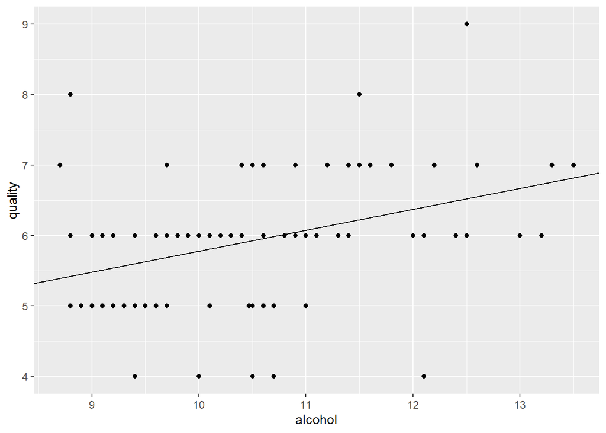

```r
m <- coef(myModel)["alcohol"]               # used in loop

b <- coef(myModel)["(Intercept)"]           # used in loop

mySample %>%
  ggplot(aes(alcohol, quality)) +
  geom_point() +
  geom_abline(intercept = b, slope = m)
```

#### 1.3.2.2 Pulling out statistics from the `lm` object

```r
myModelSummary <- summary(myModel)

names(myModelSummary)
```

```
##  [1] "call"          "terms"         "residuals"     "coefficients"
##  [5] "aliased"       "sigma"         "df"            "r.squared"
##  [9] "adj.r.squared" "fstatistic"    "cov.unscaled"
```

```r
myModelSummary["coefficients"]
```

```
## $coefficients
##              Estimate Std. Error  t value     Pr(>|t|)
## (Intercept) 2.8138307 0.71134555 3.955645 1.443999e-04
## alcohol     0.2964768 0.06720704 4.411396 2.638245e-05
```

```r
myModelSummary["fstatistic"]
```

```
## $fstatistic
##    value    numdf    dendf
## 19.46041  1.00000 98.00000
```

## 1.4 Regression on many random samples

- slope and intercept
- standard error for each
- whatever else I think I might need

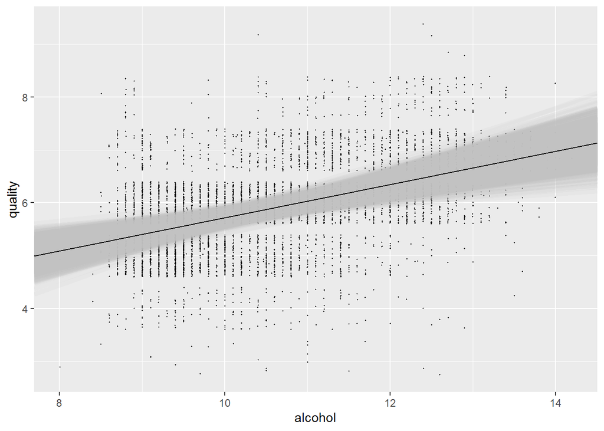

```r
set.seed(1930)


myStats <- tibble(m = double(),
                  b = double() )     # initialize a tibble ?needed

for(i in c(1:1000)){

  mySample <- sample_n(white, 100)       # take a sample
  myModel <- lm(quality ~ alcohol,       # create the model
                data = mySample)
  m <- coef(myModel)["alcohol"]          # same the slope
  b <- coef(myModel)["(Intercept)"]      # same the intercept

  myStats %>%
    add_row(m = m,
            b = b) -> myStats


}

trueModel <- lm(quality ~ alcohol, data = white)     # use the entire data set for the "true" value
trueSlope <- coef(trueModel)["alcohol"]
trueIcept <- coef(trueModel)["(Intercept)"]


# Plot all point points (x, y) = (alcohol, quality) from white
# using jitter()
myPlot <- white %>%
  ggplot(aes(x = alcohol, y = quality)) +
  geom_jitter(size = 0.2)

# plot all the lines of regression
myPlot +
  geom_abline(data = myStats,
              aes(slope = m, intercept = b),
              size = 2,
              color = "grey",
              alpha = 0.1) +
  geom_abline(aes(slope = trueSlope, intercept = trueIcept))
```

##### 1.4.0.0.1 Focusing on the slope of ALL the regression lines

```r
myStats %>% ggplot() +
  geom_freqpoly(aes(x = m, y = ..density..),
                 bins = 35,
                 alpha = 0.3) +
  ggtitle("Distribution of the slope for regression lines for many samples ",
          subtitle = "white wine data set from UCI") +
          xlab ("m = slope") -> m_hist

class(m_hist)
```

```
## [1] "gg"     "ggplot"
```

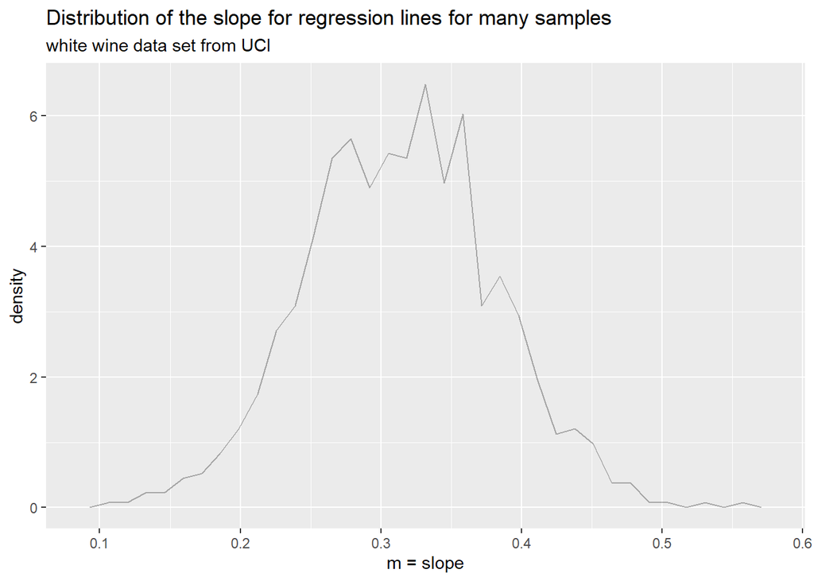

```r
m_hist
```

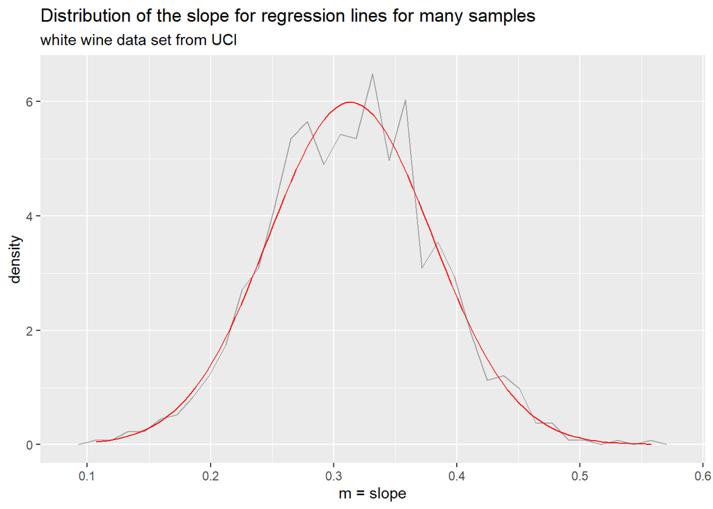

```r
m_hist +
  stat_function(fun = dnorm,
                args = list(mean(myStats$m), sd(myStats$m)),
                color = "red")
```

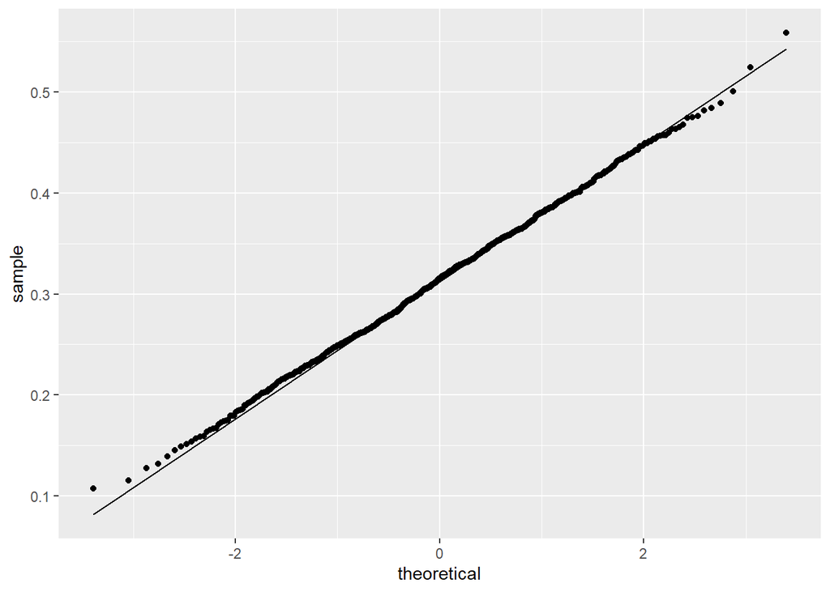

```r
myStats %>% ggplot(aes(sample = m)) +
  geom_qq(distribution = qt,
          dparams = list(df = 98)) +
  geom_qq_line(distribution = qt,
               dparams = list(df = 98))
```

#### 1.4.0.1 How does our original sample fit in?

However, we aren’t going to do 1000 regressions, we will do just one. So, how does our first regression done on a sample of 100 observations fit in with these statistics?

Here we plot our slope against the slope of the others. Assuming (from the QQ plot) that the distribution of all slopes is normal, we will also find the probability that another slope is greater than the slope from the one regression we did.

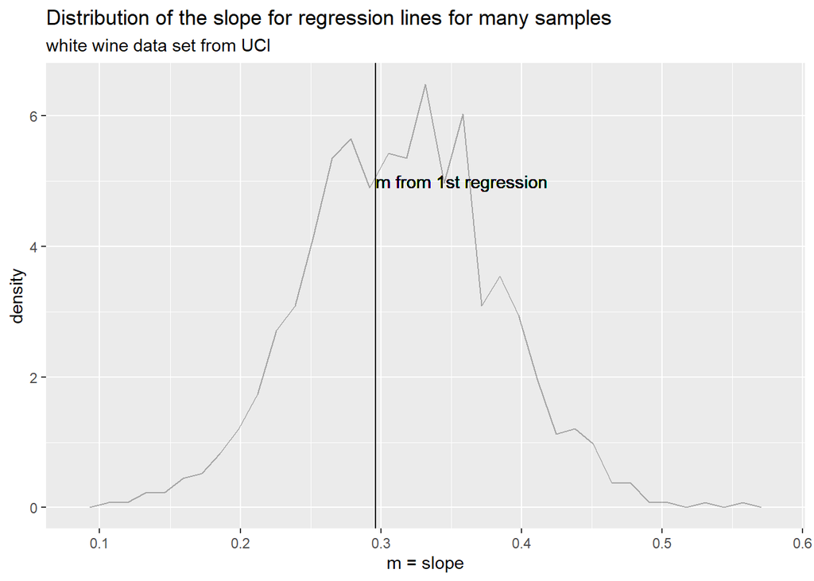

```r
set.seed(8675309) # So that we know we get the same values

mySample <- sample_n(white, 100)
myModel <- lm(quality ~ alcohol, data = mySample)
mySlope <- coef(myModel)["alcohol"]
myIcept <- coef(myModel)["(Intercept)"]

m_hist +
  geom_vline(xintercept = mySlope) +
  geom_text(aes(label = "m from 1st regression",
                x = mySlope,
                y = 5),
            hjust = "left")
```

```r
m_avg <- mean(myStats$m)
m_sd <- summary(myModel)$coefficients[["alcohol", "Std. Error"]]
m_sd
```

```
## [1] 0.06720704
```

```r
m_z <- (mySlope - 0)/m_sd
prob_norm <- 1 - pnorm(m_z)
prob_studentt <- 1 - pt(m_z, df = 98)


mySlope; m_sd^2; m_z; prob_norm; prob_studentt; summary(myModel)$coefficients
```

```
##   alcohol
## 0.2964768
```

```
## [1] 0.004516787
```

```
##  alcohol
## 4.411396
```

```
##      alcohol
## 5.135326e-06
```

```
##      alcohol
## 1.319122e-05
```

```
##              Estimate Std. Error  t value     Pr(>|t|)
## (Intercept) 2.8138307 0.71134555 3.955645 1.443999e-04
## alcohol     0.2964768 0.06720704 4.411396 2.638245e-05
```

```r
m_z
```

```
##  alcohol
## 4.411396
```

# 2 Exercises

1. What does the `R` function `str()` do? The function `class()`?
2. Why is the `white` data in horizontal strips?
3. What is the purpose of `set.seed()` in this context?
4. Explain when to use a pipe ( %>% ) and a layer ( + ).  
   What is the difference and when do we use each?
5. Explain the difference between `a -> b` and `b <- a`.
6. What is the advantage of storing a `ggplot` object?

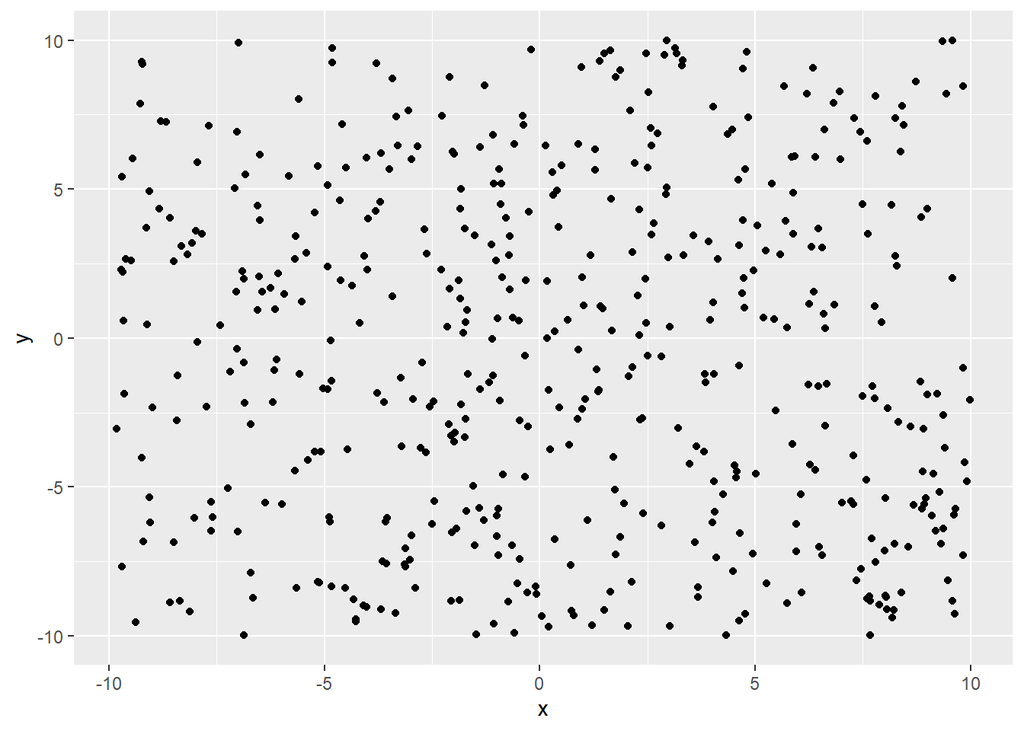

```r
set.seed(1951)
data <- tibble(x = runif(500, min = -10, max = 10),
               y = runif(500, min = -10, max = 10))



graph <- data %>%
  ggplot(aes(x, y)) +
  geom_jitter()

graph
```

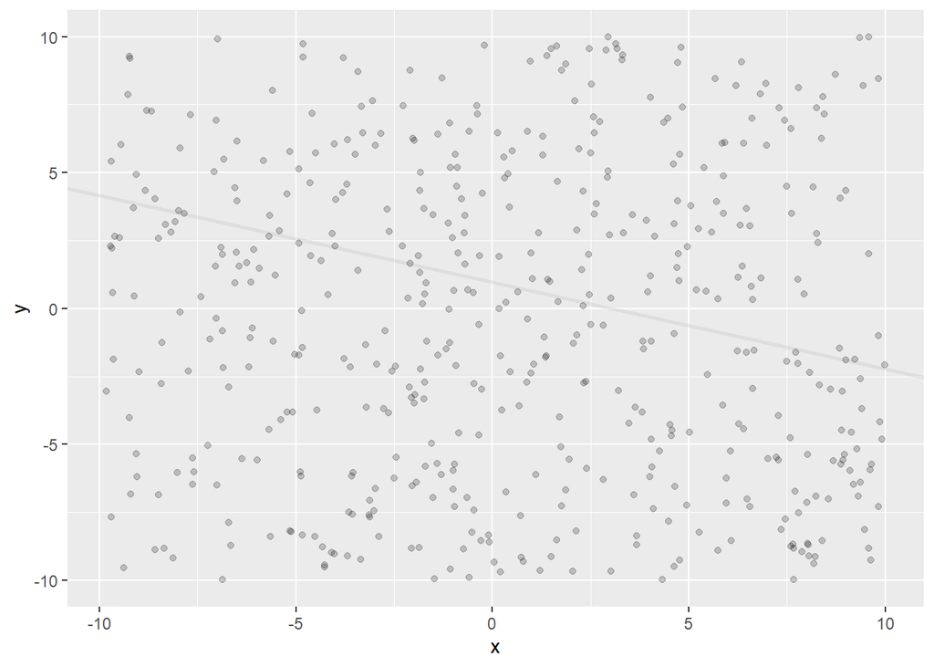

```r
myStats <- tibble(index = integer(),
                  m = double(),
                  b = double() )     # initialize a tibble
for(i in 1:1){
  mySample <- sample_n(data, 10)
  myModel <- lm(y ~ x, data = mySample)
  m <- coef(myModel)["x"]          # same the slope
  b <- coef(myModel)["(Intercept)"]      # same the intercept
    myStats %>%
    add_row(index = i,
            m = m,
            b = b) -> myStats
}

# plot all the lines of regression
data %>%
  ggplot() +
  geom_abline(data = myStats,
              aes(slope = m, intercept = b),
              size = 1,
              color = "grey",
              alpha = 0.3) +
  geom_point(aes(x, y),
             alpha = 0.2)
```

```r
str(myModel)
```

```
## List of 12
##  $ coefficients : Named num [1:2] 0.959 -0.319
##   ..- attr(*, "names")= chr [1:2] "(Intercept)" "x"
##  $ residuals    : Named num [1:10] -3.41 -3.19 -4.24 7.04 6.11 ...
##   ..- attr(*, "names")= chr [1:10] "1" "2" "3" "4" ...
##  $ effects      : Named num [1:10] -2.59 6.12 -2.8 7.45 7.66 ...
##   ..- attr(*, "names")= chr [1:10] "(Intercept)" "x" "" "" ...
##  $ rank         : int 2
##  $ fitted.values: Named num [1:10] 0.679 -1.046 -1.28 2.167 -1.649 ...
##   ..- attr(*, "names")= chr [1:10] "1" "2" "3" "4" ...
##  $ assign       : int [1:2] 0 1
##  $ qr           :List of 5
##   ..$ qr   : num [1:10, 1:2] -3.162 0.316 0.316 0.316 0.316 ...
##   .. ..- attr(*, "dimnames")=List of 2
##   .. .. ..$ : chr [1:10] "1" "2" "3" "4" ...
##   .. .. ..$ : chr [1:2] "(Intercept)" "x"
##   .. ..- attr(*, "assign")= int [1:2] 0 1
##   ..$ qraux: num [1:2] 1.32 1.3
##   ..$ pivot: int [1:2] 1 2
##   ..$ tol  : num 1e-07
##   ..$ rank : int 2
##   ..- attr(*, "class")= chr "qr"
##  $ df.residual  : int 8
##  $ xlevels      : Named list()
##  $ call         : language lm(formula = y ~ x, data = mySample)
##  $ terms        :Classes 'terms', 'formula'  language y ~ x
##   .. ..- attr(*, "variables")= language list(y, x)
##   .. ..- attr(*, "factors")= int [1:2, 1] 0 1
##   .. .. ..- attr(*, "dimnames")=List of 2
##   .. .. .. ..$ : chr [1:2] "y" "x"
##   .. .. .. ..$ : chr "x"
##   .. ..- attr(*, "term.labels")= chr "x"
##   .. ..- attr(*, "order")= int 1
##   .. ..- attr(*, "intercept")= int 1
##   .. ..- attr(*, "response")= int 1
##   .. ..- attr(*, ".Environment")=<environment: R_GlobalEnv>
##   .. ..- attr(*, "predvars")= language list(y, x)
##   .. ..- attr(*, "dataClasses")= Named chr [1:2] "numeric" "numeric"
##   .. .. ..- attr(*, "names")= chr [1:2] "y" "x"
##  $ model        :'data.frame':   10 obs. of  2 variables:
##   ..$ y: num [1:10] -2.73 -4.24 -5.52 9.21 4.46 ...
##   ..$ x: num [1:10] 0.875 6.282 7.015 -3.785 8.173 ...
##   ..- attr(*, "terms")=Classes 'terms', 'formula'  language y ~ x
##   .. .. ..- attr(*, "variables")= language list(y, x)
##   .. .. ..- attr(*, "factors")= int [1:2, 1] 0 1
##   .. .. .. ..- attr(*, "dimnames")=List of 2
##   .. .. .. .. ..$ : chr [1:2] "y" "x"
##   .. .. .. .. ..$ : chr "x"
##   .. .. ..- attr(*, "term.labels")= chr "x"
##   .. .. ..- attr(*, "order")= int 1
##   .. .. ..- attr(*, "intercept")= int 1
##   .. .. ..- attr(*, "response")= int 1
##   .. .. ..- attr(*, ".Environment")=<environment: R_GlobalEnv>
##   .. .. ..- attr(*, "predvars")= language list(y, x)
##   .. .. ..- attr(*, "dataClasses")= Named chr [1:2] "numeric" "numeric"
##   .. .. .. ..- attr(*, "names")= chr [1:2] "y" "x"
##  - attr(*, "class")= chr "lm"
```

```r
myExamples <- read_csv("C:/Users/DCama/Documents/MATH-308-Adv-Data-Modeling/Ch 3/ISLR Ch 3 Lab 2 RegressionExamples.csv")
myExStats <- tibble(id = double(),
                  m = double(),
                  b = double() )     # initialize a tibble
for(i in 1:4){
  mySample <- filter(myExamples, str_detect(id, as.character(i)))
  myModel <- lm(y ~ x, data = mySample)
  m <- coef(myModel)["x"]          # same the slope
  b <- coef(myModel)["(Intercept)"]      # same the intercept
    myExStats %>%
    add_row(id = i,
            m = m,
            b = b) -> myExStats
}

myExStats
```

```
## # A tibble: 4 x 3
##      id         m     b
##   <dbl>     <dbl> <dbl>
## 1     1 -0.494    -1.59
## 2     2  0.000921 -2.76
## 3     3  0.472     1.88
## 4     4  0.589    -2.64
```

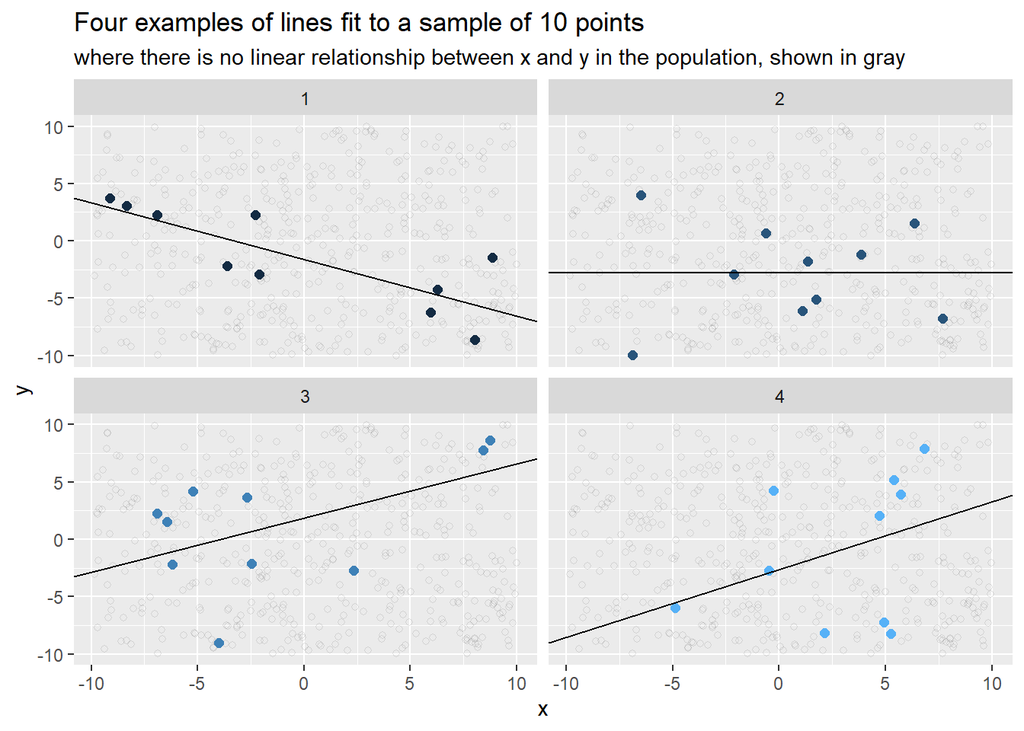

```r
myExamples %>%
  ggplot(aes(x, y)) +
  geom_jitter(data = data,
             aes(x,y),
             alpha = 0.1,
             shape = 1) +
  geom_point(aes(color = id),
             size = 2) +
  geom_abline(data = myExStats,
              aes(slope = m,
                  intercept = b))  +
  facet_wrap(~id) +
  theme(legend.position="none") +
  ggtitle("Four examples of lines fit to a sample of 10 points",
        "where there is no linear relationship between x and y in the population, shown in gray")
```